# 1-deep-visualization-data-processing

#### The Aim of this kernel is to cover Visualization and Data processing.

##### We'll see how to interpret different set of plots for different use case , impute the missing data, find and remove outliers. This helps in producing better model and high accuracy. Let's dive in.

##### Please upvote if you like this Kernel. Thanks in advance.

#### Competition description:

Ask a home buyer to describe their dream house, and they probably won't begin with the height of the basement ceiling or the proximity to an east-west railroad. But this playground competition's dataset proves that much more influences price negotiations than the number of bedrooms or a white-picket fence.

With 79 explanatory variables describing (almost) every aspect of residential homes in Ames, Iowa, this competition challenges you to predict the final price of each home.

## These are the steps We'll focus on this kernel. Let's start !!!

#### 1. Univariate Analysis

#### 2. Bivariate Analysis

#### 3. Imputing missing values

#### 4. Fix Skewed features

#### 5. Feature Creation

#### 6. Feature Transformation

#### 7. Model Prediction

```python
#importing necessary models and libraries

#Math tools
from scipy import stats
from scipy.stats import skew,norm  # for some statistics
from scipy.special import boxcox1p
from scipy.stats import boxcox_normmax
import scipy.stats as stats


#Visualizing tools
import seaborn as sns
import matplotlib.pyplot as plt
import matplotlib.gridspec as gridspec
from matplotlib.patches import Rectangle
sns.set(style="ticks")

#preprocessing tools
import pandas as pd
import numpy as np

from sklearn.preprocessing import LabelEncoder
```

```python
train = pd.read_csv("../input/house-prices-advanced-regression-techniques/train.csv")
test = pd.read_csv("../input/house-prices-advanced-regression-techniques/test.csv")
train_size = train.shape[0]
submission = pd.read_csv("../input/house-prices-advanced-regression-techniques/sample_submission.csv")

import warnings
warnings.filterwarnings(action="ignore")
```

#### 1. Univariate Analysis

Our first step in Machine Learning should always be analyzing the target variable. Saleprice is our given target/dependent variable.

Let's analyse its distribution

```python
#skewness and kurtosis
print("Skewness: {}".format(train['SalePrice'].skew()))
print("Kurtosis: {}".format(train['SalePrice'].kurt()))
print("--------------------------------------")
print(train['SalePrice'].describe())
```

```
Skewness: 1.8828757597682129
Kurtosis: 6.536281860064529
--------------------------------------
count      1460.000000
mean     180921.195890
std       79442.502883
min       34900.000000
25%      129975.000000
50%      163000.000000
75%      214000.000000
max      755000.000000
Name: SalePrice, dtype: float64
```

##### skew data makes a model difficult to find a proper pattern in the data that's why we convert skew data into normal(Gaussian) distribution

```python
# Customizing the layout
def multi_plot(feature):
    fig = plt.figure(constrained_layout=True, figsize=(15,10))
    grid = gridspec.GridSpec(ncols=4, nrows=2, figure=fig)

    ax1 = fig.add_subplot(grid[0, :2])
    ax1.set_title('Distplot')
    sns.distplot(train.loc[:,feature], fit=norm,color="mediumseagreen", ax = ax1)

    ax2 = fig.add_subplot(grid[1, :2])
    ax2.set_title('QQ_plot')
    stats.probplot(train.loc[:,feature], plot = ax2)

    ax3= fig.add_subplot(grid[0, 2:])
    ax3.set_title('Scatter Plot')
    sns.scatterplot(range(train.shape[0]), train[feature].values,color='orangered')

    ax4 = fig.add_subplot(grid[1, 2:])
    ax4.set_title('Box Plot')
    sns.boxplot(train.loc[:,feature], orient='v', ax = ax4 , color='darkorange');
```

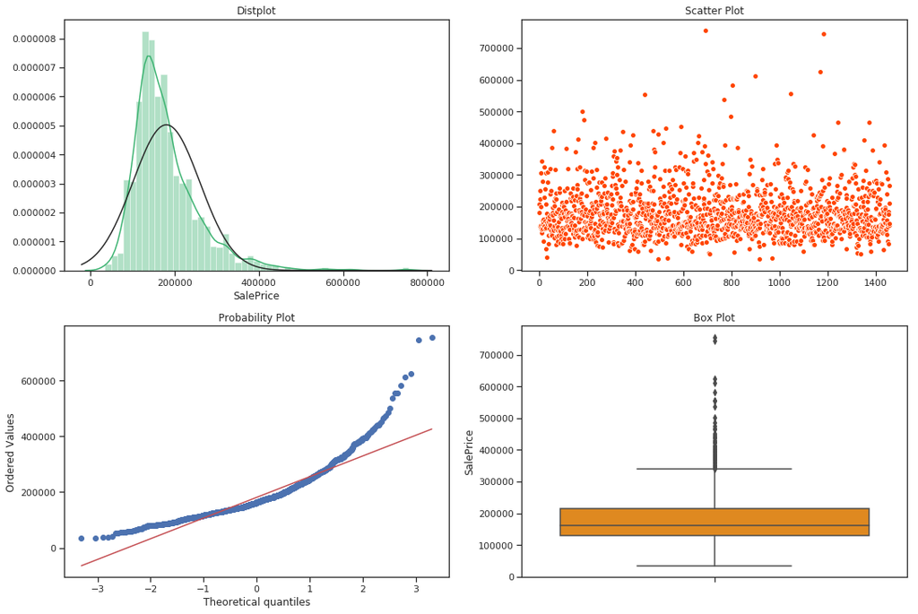

```python
multi_plot('SalePrice')
```

##### Observations:

- Target variable is not normally distributed.
- It is rightly skewed.
- Average sell price is 180921 USD which pulled towards outliers values at the upper end.
- Median 163000 USD which is lower than Mean value.
- It has couple of outliers at the upper end.

#### 2. Bivariate Analysis

Let's analyse how the other independent/predictor/input variable correleated with the Target variable

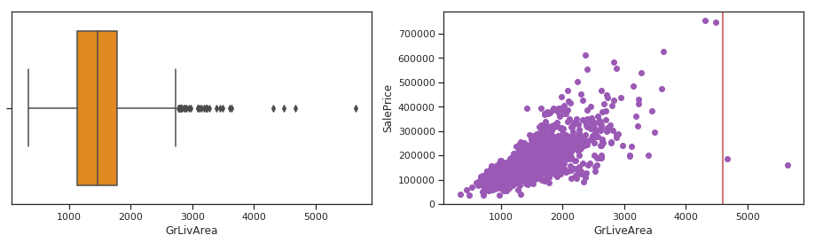

```python
f,ax = plt.subplots(1,2,figsize=(16,4))
sns.boxplot(train['GrLivArea'],ax=ax[0],color="darkorange")
plt.scatter(train['GrLivArea'],train['SalePrice'],color='#9b59b6')
#outlier detection
plt.axvline(x=4600,color='r')
plt.xlabel('GrLiveArea')
plt.ylabel('SalePrice')
plt.show()
```

##### observations :

We can see that SalePrice increases along with GrLiveArea but after 4500sq ft, the SalePrice seems below 200000USD which will surely affect our model Predictions. So, We remove it.

```python
#outlier removal
train.drop(train[train['GrLivArea']>4500].index,axis=0,inplace=True)
```

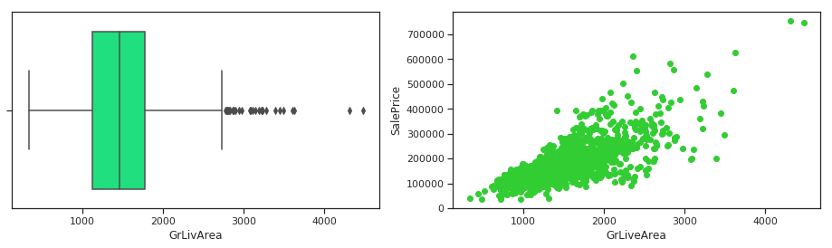

```python
f,ax = plt.subplots(1,2,figsize=(16,4))
sns.boxplot(train['GrLivArea'],ax=ax[0],color="springgreen")
plt.scatter(train['GrLivArea'],train['SalePrice'],color='limegreen')
plt.xlabel('GrLiveArea')
plt.ylabel('SalePrice')
plt.show()
```

How to plot relationship between numerical data and categorical dataa ?

#### Rectangle :

Rectangle is a shape available in matplotlib which is used to highlight a point or set of points.

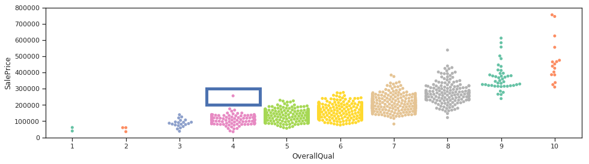

```python
f,ax = plt.subplots(1,1,figsize=(16,4))
# Uncomment the below line and see why Swarmplot was suggested instead of Scatterplot,
# when using on discrete or categorical variable.
# sns.scatterplot('OverallQual','SalePrice', data = train)
sns.swarmplot('OverallQual','SalePrice', data = train , palette="Set2")


#outlier detection
ax.add_patch(Rectangle((2.5,200000),1,100000 ,linewidth=5,edgecolor='b',facecolor='none'))
plt.xlabel('OverallQual')
plt.ylabel('SalePrice')
plt.show()
```

##### Observation :

Distribution shows that, Less number of people who bought the house when the OverallQual is less than 4. So they are not interested for lower quality. Even price looks cheaper people prefer Quality.

Most of the people bought the house between the OverallQual 4 to 8. There is a slight increase in price When quality increase. So money and quality balanced here.

Less number of people who bought the the house when the OverallQual are at top 9 and 10. There is drastic change in price when the quality is at 10. People shows less interest because Price seems too high.

```python
outlier_index = train[(train['OverallQual'] == 4) & (train['SalePrice'] > 200000)].index

# *outlier
# We can see OverallQual increases along with SalePrice and the pattern shows that each qual level covers the previous levels completely
# but on index 457(highlighted rectangle) looks different. so we will remove it .

# outlier removal
train.drop(outlier_index,axis=0,inplace=True)
```

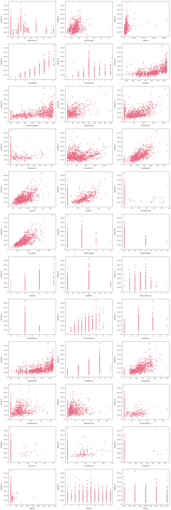

```python
# Finding numeric features
numeric_cols = train.select_dtypes(exclude='object').columns
numeric_cols_length = len(numeric_cols)

fig, axs = plt.subplots(ncols=2, nrows=0, figsize=(12, 120))
plt.subplots_adjust(right=2)
plt.subplots_adjust(top=2)

# skiped Id and saleprice feature
for i in range(1,numeric_cols_length-1):
    feature = numeric_cols[i]
    plt.subplot(numeric_cols_length, 3, i)
    sns.scatterplot(x=feature, y='SalePrice', data=train,color='crimson')
    plt.xlabel('{}'.format(feature), size=15,labelpad=12.5)
    plt.ylabel('SalePrice', size=15, labelpad=12.5)

plt.show()
```

##### Observations:

- MSSubClass,MoSold,YrSold - patterns shows it as a category and description meant the same
- OverallQual, OverallCond - Ordered value (like ratings)
- BsmtFullBath,BsmtHalfBath,FullBath,HalfBath,Fireplaces,BedroomAbvGr,KitchenAvbGr - discrete value(no. of bathrooms)

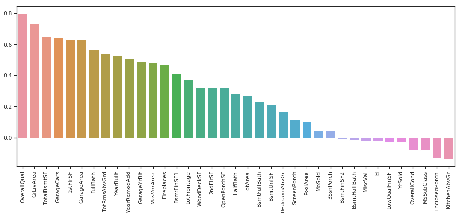

```python
corr = train.select_dtypes(include='number').corr()
plt.figure(figsize=(16,6))
corr_saleprice = corr['SalePrice'].sort_values(ascending=False)[1:]
ax = sns.barplot(corr_saleprice.index,corr_saleprice.values)
ax.set_xticklabels(ax.get_xticklabels(), rotation=90)
plt.show()
```

#### Zoomed Heat Map

Zoomed heat map is nothing but a heat map with n number of features. This will help in finding the top correlated features.

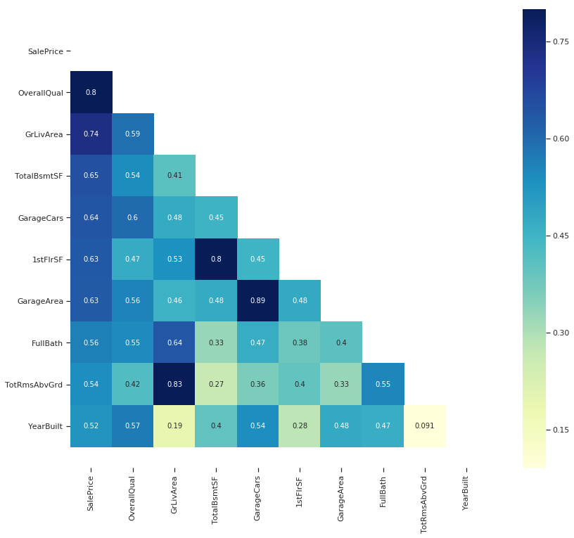

```python
# # Correlation of top 10 feature with saleprice
corWithSalePrice = train.corr().nlargest(10,'SalePrice')['SalePrice'].index
f , ax = plt.subplots(figsize = (18,12))
corr = train[corWithSalePrice].corr()
mask = np.zeros_like(corr)
mask[np.triu_indices_from(mask)] = True
with sns.axes_style("white"):
    ax = sns.heatmap(corr, mask=mask, vmax=0.8,square=True,annot=True,cmap="YlGnBu")
bottom, top = ax.get_ylim()
ax.set_ylim(bottom + 0.5, top - 0.5)
plt.show()
```

##### Observations

- OverallQual, GrLivArea , GarageCars , GarageArea and TotalBsmtSF are strongly correlated with the SalePrice.
- GarageCas and GarageArea are strongly correlated this is because of parking the Garage cars at the GarageArea.
- TotRmsAbvGrd and GrLivArea are strongly correleated. When the Ground area increases count of rooms also increases.
- TotalBsmtSF and 1stFlrSF are strongly correleated.

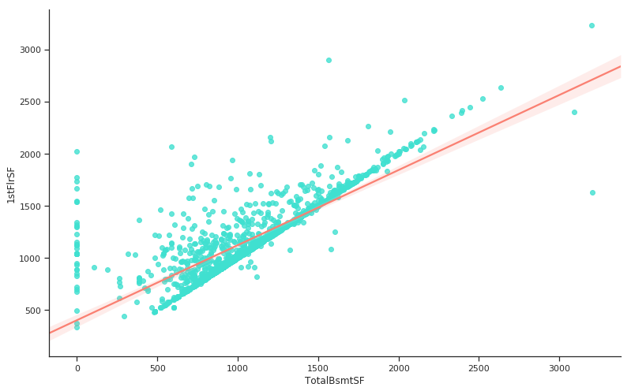

```python
sns.lmplot('TotalBsmtSF','1stFlrSF',data=train,height=7, aspect=1.6, palette="Set1" ,
           line_kws={'color': 'salmon'},scatter_kws={'color': 'turquoise'})
```

##### Observations

- TotalBsmtSF and 1stFlrSF are strongly correleated.

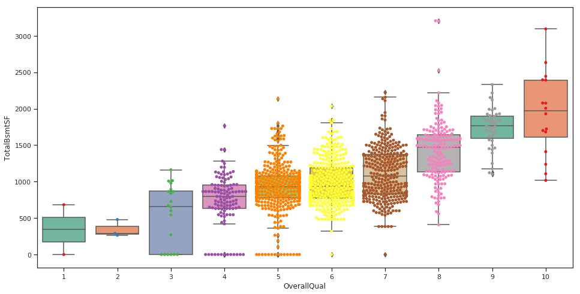

```python
plt.figure(figsize=(16,8))
sns.boxplot(x='OverallQual', y='TotalBsmtSF',data=train,palette='Set2')
sns.swarmplot(x='OverallQual', y='TotalBsmtSF',data=train,palette='Set1')
plt.show()
```

##### Stripplot :

Stripplot is basically a scatter plot where the x axis represents a categorical variable. It's function is similar to Swarmplot(). Unlike Swarmplot, you can see the points overlap.

###### This will give clear picture since there is a separation between each point

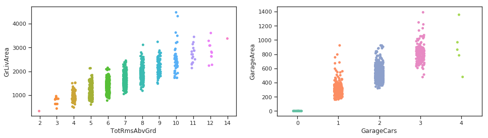

```python
f,ax = plt.subplots(1,2,figsize=(16,4))
sns.stripplot('TotRmsAbvGrd','GrLivArea',data=train,ax=ax[0])
sns.stripplot('GarageCars','GarageArea',data=train,ax = ax[1], palette="Set2")
plt.show()
```

##### Observations :

- When the GrLiveArea increase obviously Builder builds more rooms to sell it in high price.
- When the GarageArea increases People can able to park more cars.
- When there is no GarageArea then people can't park their cars on Garage.

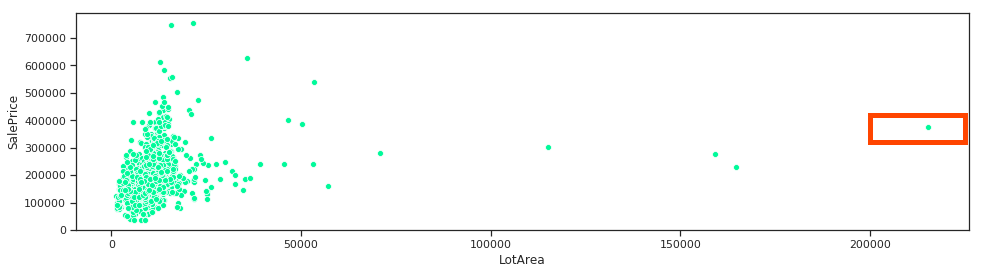

```python
f,ax = plt.subplots(1,1,figsize=(16,4))
sns.scatterplot(x='LotArea', y='SalePrice',data=train,color='mediumspringgreen')

#outlier detection
ax.add_patch(Rectangle((200000,320000),25000,100000 ,linewidth=5,edgecolor='orangered',facecolor='none'))
plt.show()
```